# Расчет емкости плотного слоя воды на поверхности электрода Au(111) в рамках модели Грэма

```python
%matplotlib notebook

import matplotlib as mpl
import matplotlib.pyplot as plt
from scipy.interpolate import interp1d
import numpy as np

# matplotlib plotting parameters
mpl.rcParams['text.usetex'] = True
mpl.rcParams['text.latex.unicode'] = True

mpl.rcParams['font.family'] = 'serif'
mpl.rcParams['font.serif'] = 'Times'
mpl.rcParams['figure.titlesize'] = 'xx-large'
mpl.rcParams['axes.labelsize'] = 'x-large'
mpl.rcParams['axes.titlesize'] = 'large'
mpl.rcParams['xtick.labelsize'] = 'large'
mpl.rcParams['ytick.labelsize'] = 'large'
```

В растворе поверхностно-неактивного электролита в гальвани-потенциале $\Delta \varphi$ выделяют следующие три составляющие:

- разность потенциалов $\Delta \varphi_{\text{мет}}$, обусловленная выходом электронной плотности за пределы ионного остова металла
- разность потенциалов $\Delta \varphi_{\text{дип}}$, вызванная некоторой предпочтительной ориентацией примыкающих к электроду диполей растворителя
- разность потенциалов, обусловленная зарядом электрода $q$ и компенсирующими этот заряд ионами раствора. Выделяют гельмгольцевскую составляющую $\Delta \varphi_H$ (от поверхности металла $x = 0$ до внешней плоскости Гельмгольца $x = x_2$; (модель Штерна) на внутренней плоскости Гельмгльца локализуются центры специфически адсорбированных ионов; а внешняя плоскость Гельмгольца представляет собой границу максимального приближения ионов, находящихся в диффузной части двойного слоя и участвующих в тепловом движении) и падение потенциала в диффузном слое $\Delta \varphi_2$

При заряде электрода $q$ гальвани-потенциал $\left( \Delta \varphi \right)_q$ представляет собой сумму $$ \left( \Delta \varphi \right)_q = \left( \Delta \varphi_{\text{мет}} \right)_q + \left( \Delta \varphi_{\text{дип}} \right)_q + \left( \Delta \varphi_H + \varphi_2 \right). $$

При потенциале нулевого заряда ($pzc$) последние два слагаемые обнуляются $\Delta \varphi_H = 0$, $\Delta \varphi_2 = 0$. Таким образом, потенциал электрода $\varphi_0$, измеренный относительно потенциала нулеового заряда, представится в виде: $$ \varphi_0 = \left( \left( \Delta \varphi_{\text{мет}} \right)_q - \left( \Delta \varphi_{\text{мет}} \right)_{q=0} \right) + \left( \left( \Delta \varphi_{\text{дип}} \right)_q - \left( \Delta \varphi_{\text{дип}} \right)_{q=0} \right) + \left( \Delta \varphi_H + \varphi_2 \right). $$

Модель Грэма предполагает, что первые два скачка потенциала не зависят от заряда электрода; выражение для разности потенциалов $\varphi_0$ переписывается следующим образом: $$ \varphi_0 = \varphi_{02} + \varphi_2 $$

Данные по зависимости емкости $C$ от потенциала $\varphi$ (относительно каломельного электрода) были взяты из статьи [1] (рис. 8а, линия 1). В результате оцифровки рисунка получаем массив точек, который профитуем кубическим сплайном.

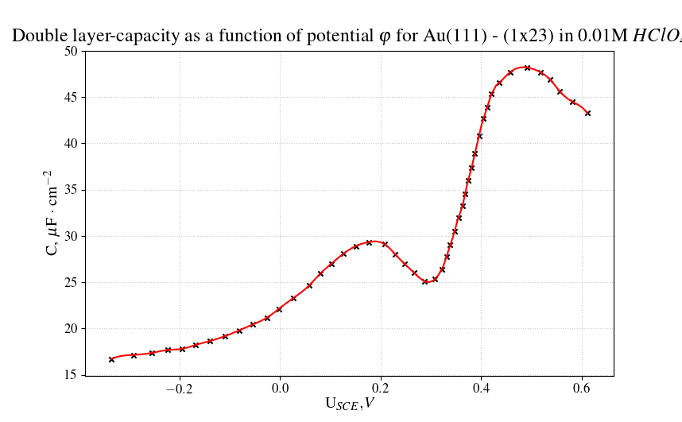

```python
data = np.loadtxt("kolb1986_figure8.csv", delimiter = ',')
phi = data[:,0]
C = data[:,1]

spline = interp1d( phi, C, kind = 'cubic' )
x_val = np.linspace( min(phi), max(phi), 100 )
y_val = spline(x_val)

fig = plt.figure()
plt.title(r'\LARGE Double layer-capacity as a function of potential $\varphi$ for Au(111) - (1x23) in 0.01M $HClO_4$')
plt.xlabel(r'U_{SCE}, V')
plt.ylabel(r'C, $\mu$F $\cdot$ cm$^{-2}$')
plt.plot( x_val, y_val, color = 'r' )
plt.scatter( phi, C, color = 'k', marker = 'x', s = 20 )
plt.grid( linestyle = ':', alpha = 0.7 )
```

Электродный потенциал, при котором на поверхности элеткрода нет свободных зарядов $(q = 0)$, называется потенциалом нулевого заряда $E_{q = 0}$. Авторы [1] приводят значение потенциала нулевого заряда $pzc = +0.32$ В. Зависимость заряда электрода $q$ от потенциала $\varphi$ была рассчитана интегрированием методом трапеций емкости $C$ по напряжению $\varphi$ от потенциала нулевого электрода $pzc$: $$ q(\varphi) = \int\limits_{pzc}^{\varphi} C ( \varphi^\prime) \, d \varphi^\prime $$

Красным крестиком отмечено значение потенциала нулевого заряда $pzc$.

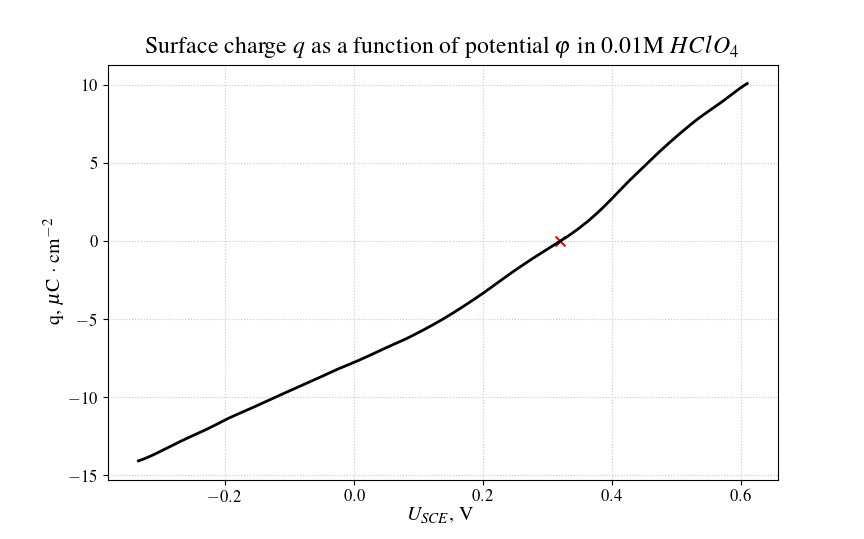

```python
def integrate( f, x0, x1 ):
    return 0.5 * (x1 - x0) * (f(x0) + f(x1))

pzc = 0.32 # V
N = 300
phi_values, q_values = [], []

for i in range(N - 1):
    phi_value = phi[0] + (pzc - phi[0]) / (N - 1) * i
    q_value = integrate( spline, phi_value, pzc )
    phi_values.append( phi_value )
    q_values.append( -q_value )

for i in range(N - 1):
    phi_value = pzc + (phi[-1] - pzc) / (N - 1) * i
    q_value = integrate( spline, pzc, phi_value )
    phi_values.append( phi_value )
    q_values.append( q_value )

fig = plt.figure()
plt.title(r'\LARGE Surface charge $q$ as a function of potential $\varphi$ in 0.01M $HClO_4$')
plt.xlabel(r'$U_{SCE}$, V')
plt.ylabel(r'q, $\mu$C $\cdot$ cm$^{-2}$')
plt.plot( phi_values, q_values, color = 'k', lw = 2.0 )
plt.scatter( [pzc], [0.0], color = 'r', marker = 'x', s = 50 )
plt.grid( linestyle = ':', alpha = 0.7 )
```

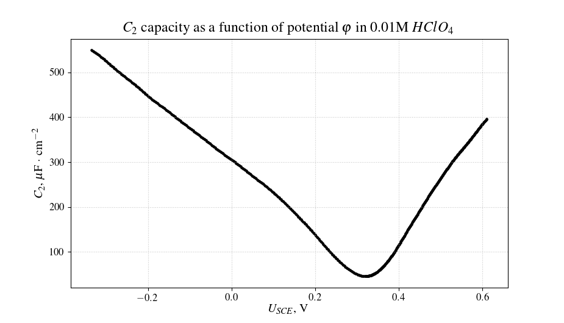

```python
F = 96485.33289 # C * mol^{-1}
R = 8.314 # J * mol^{-1}
T = 298 # K
A = 5.87 # for H2O, 298 K
c_hclo4 = 0.01

C2_values = [ F / (R * T) * np.sqrt( 4 * A**2 * c_hclo4 + q**2 ) for q in q_values ]

fig = plt.figure()
plt.title(r'\LARGE $C_2$ capacity as a function of potential $\varphi$ in 0.01M $HClO_4$')
plt.xlabel(r'$U_{SCE}$, V')
plt.ylabel(r'$C_2$, $\mu$F $\cdot$ cm$^{-2}$')
plt.scatter( phi_values, C2_values, color = 'k',  marker = 'o', s = 5 )
plt.grid(linestyle = ':', alpha = 0.7)
```

Затем, используя связь полной емкости $C$ с емкостями $C_2$ и $C_{20}$, выразим емкость плотного слоя $C_{20}$ при каждом значении потенциала $\varphi$ (предварительно рассчитав значения полной емкости $C$ на массиве значений потенциала $\varphi$ при помощи ранее построенного сплайна): $$ \frac{1}{C} = \frac{1}{C_{02}} + \frac{1}{C_2} \quad \implies \quad C_{20} = \frac{C \cdot C_2}{C_2 - C} $$

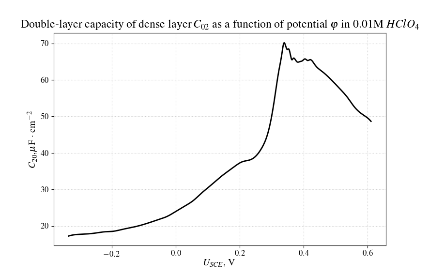

```python
C_values = spline(phi_values)
C20_values = [ c * c2 / (c2 - c) for c, c2 in zip( C_values, C2_values )]

fig = plt.figure()
plt.title(r'\LARGE Double-layer capacity of dense layer $C_{02}$ as a function of potential $\varphi$ in 0.01M $HClO_4$')
plt.xlabel(r'$U_{SCE}$, V')
plt.ylabel(r'$C_{20}, $\mu$F $\cdot$ cm$^{-2}$')
plt.plot( phi_values, C20_values, color = 'k', lw = 2.0 )
plt.grid(linestyle = ':', alpha = 0.7)
```

Уравнение полуреакции, протекающей на каломельном электроде, имеет вид $$ Hg_2^{2+} + 2 e^{-} \rightleftharpoons 2 Hg^{0}. $$

Уравнение Нернста записывается для него следующим образом $$ E = E_{Hg_2^2{2+}/Hg}^0 + \frac{RT}{2F} \ln a_{Hg_2^{2+}} $$

Так как каломель является малорастворимым соединением, активность ионов $Hg_2^{2+}$ связана с активностью хлорид-ионов через величину проивзедения растворимости $K_{sp}$: $$ E = E^0_{Hg_2^{2+} / Hg} + \frac{RT}{2F} \ln K_{sp} - \frac{RT}{2F} \ln a_{Cl^{-}}^2, $$

где $E^0$ -- стандартный электродный потенциал процесса. Используют насыщенный раствор KCl, в этом случае потенциал насыщенного каломельного электрода составляет $E = 0.2412$ В при $T = 298$ K.

Перестроим последний график зависимости емкости плотного слоя $C_{20}$ от потенциала $\varphi$ относительно стандартного ВЭ.

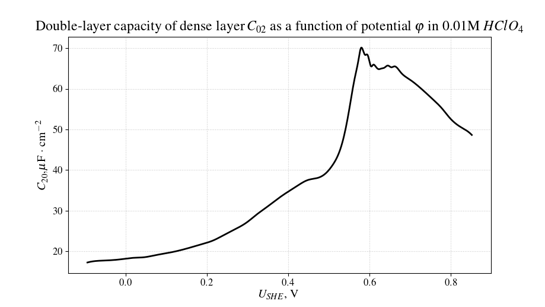

```python
phi_values_he = [ p + 0.2412 for p in phi_values ]

fig = plt.figure()
plt.title(r'\LARGE Double-layer capacity of dense layer $C_{02}$ as a function of potential $\varphi$ in 0.01M $HClO_4$')
plt.xlabel(r'$U_{SHE}$, V')
plt.ylabel(r'$C_{20}, $\mu$F $\cdot$ cm$^{-2}$')
plt.plot( phi_values_he, C20_values, color = 'k', lw = 2.0 )
plt.grid(linestyle = ':', alpha = 0.7)
```

В работе [2] определялись параметры ультрабыстрой релаксации возбужденных электронов на поверхности электрода Au(111) в зависимости от потенциала электрода $\varphi$ в растворе HClO$_4$. Был использован $Pt$ электрод, имеющий потенциал $+0.7$ В относительно стандартного ВЭ. На первой картинке изображен отклик поверхности в зависимости от времени между лазерными импульсами.

[figure not shown]

На следующем рисунке изображена зависимость времени затухания отклика от потенциала электрода. (Нас интересует первая зависимость -- круглые точки -- отнсящаяся к чистому раствору HClO$_4$.) На графике емкости плотного слоя по Грэму мы видим пик в области 0.5-0.8В относительно СВЭ, это соотвествует (-0.2)-0.1В относительно Pt электрода. В этой области на графике зависимости времени затухания от потенциала наблюдается практически плато.

[figure not shown]

## Список литературы

$1.\ \text{D. M. Kolb, J. Schneider.} \ \textit{Electrochimica Acta}, \textbf{31}, 8, 1986, 929-936$ $2.\ \text{T. Sugiyama, T. Ishioka, A. Harata.} \ \textit{Analytical Sciences}, \textbf{17}, 2001, 237-240$